# Kisoken2016:Speaking Anxiety

Yu Tamura

March 18, 2017

This document describes the analysis of speaking anxiety data reporeted in Tamura (2017).

### 0.0.1 Prepare necessary packages

```r
#If you haven't installed the packages, please install first. If you have, you don't need to install the packages
install.packages("dplyr")
install.packages("mice")
install.packages("VIM")
install.packages("psychometric")
install.packages("psych")
install.packages("rlist")
install.packages("coin")
```

```r
#Read packages
library(dplyr)
library(mice)
library(VIM)
library(psychometric)
library(psych)
library(rlist)
library(coin)
```

# 1 Read the data

```r
april<-read.csv("H27_speaking-anxiety_April.csv",header=T,sep=",")
july<-read.csv("H27_speaking-anxiety_July.csv",header=T,sep=",")
big5<-read.csv("H27_BIG5_results.csv",header=T,sep = ",")
```

# 2 Check the students who demonstrate no variance for all the responses

```r
april$var<-apply(april[,-1],1,var)
july$var<-apply(july[,-1],1,var)

april%>%
  filter(var==0)%>%
  dplyr::select(ID)
```

```
##   ID
## 1  9
## 2 19
```

```r
july%>%
  filter(var==0)%>%
  dplyr::select(ID)
```

```
## [1] ID
## <0 rows> (or 0-length row.names)
```

In the April data two students showed no variance, which means these two students marked the same number for all the items. Therefore, treat the responses as NAs. In the July data, no such student was observed.

```r
april2<-april #copy the data
april2%>%
  dplyr::filter(ID=="9")%>%
  dplyr::select(ability.1.ap:avoid.3.ap)%>%
  replace(.,values=NA)->april2[9,c(2:(ncol(april2)-1))]

april2%>%
  dplyr::filter(ID=="19")%>%
  dplyr::select(ability.1.ap:avoid.3.ap)%>%
  replace(.,values=NA)->april2[19,c(2:(ncol(april2)-1))]
```

# 3 Reliablity of the measurement

```r
alpha(april2[,-c(1,11)]) #All items
```

```
## Some items ( avoid.3.ap ) were negatively correlated with the total scale and
## probably should be reversed.
## To do this, run the function again with the 'check.keys=TRUE' option
```

```
##
## Reliability analysis
## Call: alpha(x = april2[, -c(1, 11)])
##
##   raw_alpha std.alpha G6(smc) average_r S/N ase mean   sd
##       0.66      0.69    0.84       0.2 2.2 0.1  5.4 0.74
##
##  lower alpha upper     95% confidence boundaries
## 0.47 0.66 0.86
##
##  Reliability if an item is dropped:
##              raw_alpha std.alpha G6(smc) average_r S/N alpha se
## ability.1.ap      0.63      0.65    0.82      0.19 1.8    0.111
## anxiety.1.ap      0.62      0.64    0.81      0.18 1.8    0.115
## avoid.1.ap        0.60      0.65    0.81      0.19 1.9    0.122
## ability.2.ap      0.65      0.68    0.78      0.21 2.1    0.105
## anxiety.2.ap      0.58      0.63    0.79      0.17 1.7    0.128
## avoid.2.ap        0.65      0.69    0.83      0.22 2.3    0.105
## ability.3.ap      0.61      0.62    0.73      0.17 1.6    0.115
## anxiety.3.ap      0.64      0.67    0.81      0.20 2.0    0.108
## avoid.3.ap        0.73      0.74    0.84      0.26 2.8    0.083
##
##  Item statistics
##               n raw.r std.r r.cor r.drop mean  sd
## ability.1.ap 24  0.54  0.61 0.550  0.394  5.2 1.2
## anxiety.1.ap 24  0.58  0.63 0.579  0.427  5.9 1.3
## avoid.1.ap   24  0.65  0.60 0.556  0.487  5.3 1.5
## ability.2.ap 24  0.44  0.49 0.471  0.262  6.0 1.3
## anxiety.2.ap 24  0.71  0.67 0.655  0.554  5.6 1.6
## avoid.2.ap   24  0.50  0.41 0.331  0.287  5.1 1.6
## ability.3.ap 24  0.63  0.70 0.727  0.489  5.5 1.3
## anxiety.3.ap 24  0.45  0.53 0.473  0.312  6.1 1.0
## avoid.3.ap   24  0.28  0.19 0.078  0.012  3.8 1.8
##
## Non missing response frequency for each item
##                 1    2    3    4    5    6    7 miss
## ability.1.ap 0.00 0.00 0.04 0.29 0.21 0.29 0.17 0.08
## anxiety.1.ap 0.00 0.04 0.04 0.00 0.21 0.29 0.42 0.08
## avoid.1.ap   0.00 0.08 0.04 0.12 0.21 0.29 0.25 0.08
## ability.2.ap 0.00 0.00 0.04 0.17 0.08 0.21 0.50 0.08
## anxiety.2.ap 0.04 0.00 0.04 0.12 0.21 0.17 0.42 0.08
## avoid.2.ap   0.04 0.04 0.04 0.17 0.25 0.25 0.21 0.08
## ability.3.ap 0.00 0.00 0.08 0.12 0.25 0.25 0.29 0.08
## anxiety.3.ap 0.00 0.00 0.00 0.12 0.08 0.38 0.42 0.08
## avoid.3.ap   0.17 0.08 0.12 0.29 0.17 0.08 0.08 0.08
```

```r
alpha(july[,-c(1,11)]) #All items
```

```
##
## Reliability analysis
## Call: alpha(x = july[, -c(1, 11)])
##
##   raw_alpha std.alpha G6(smc) average_r S/N   ase mean sd
##       0.86      0.85    0.93       0.4 5.9 0.041  4.6  1
##
##  lower alpha upper     95% confidence boundaries
## 0.78 0.86 0.94
##
##  Reliability if an item is dropped:
##               raw_alpha std.alpha G6(smc) average_r S/N alpha se
## ability.1.jul      0.84      0.84    0.90      0.40 5.3    0.045
## anxiety.1.jul      0.85      0.84    0.89      0.40 5.4    0.044
## avoid.1.jul        0.83      0.83    0.88      0.39 5.0    0.048
## ability.2.jul      0.82      0.83    0.91      0.37 4.7    0.051
## anxiety.2.jul      0.85      0.85    0.91      0.41 5.6    0.042
## avoid.2.jul        0.82      0.83    0.87      0.37 4.7    0.051
## ability.3.jul      0.83      0.83    0.91      0.38 4.9    0.049
## anxiety.3.jul      0.86      0.86    0.90      0.43 6.0    0.041
## avoid.3.jul        0.85      0.85    0.93      0.41 5.5    0.044
##
##  Item statistics
##                n raw.r std.r r.cor r.drop mean  sd
## ability.1.jul 19  0.66  0.66  0.64   0.55  4.2 1.6
## anxiety.1.jul 19  0.61  0.65  0.63   0.53  4.9 1.0
## avoid.1.jul   19  0.75  0.73  0.73   0.65  4.4 1.8
## ability.2.jul 19  0.81  0.79  0.77   0.73  4.9 1.7
## anxiety.2.jul 19  0.57  0.60  0.56   0.46  4.8 1.4
## avoid.2.jul   19  0.81  0.79  0.80   0.73  4.1 1.7
## ability.3.jul 19  0.76  0.75  0.72   0.69  4.7 1.4
## anxiety.3.jul 19  0.51  0.52  0.51   0.39  5.3 1.3
## avoid.3.jul   19  0.62  0.63  0.54   0.51  3.6 1.5
##
## Non missing response frequency for each item
##                  1    2    3    4    5    6    7 miss
## ability.1.jul 0.05 0.11 0.16 0.21 0.26 0.16 0.05 0.27
## anxiety.1.jul 0.00 0.00 0.05 0.32 0.32 0.26 0.05 0.27
## avoid.1.jul   0.00 0.16 0.26 0.11 0.11 0.21 0.16 0.27
## ability.2.jul 0.05 0.00 0.16 0.16 0.26 0.16 0.21 0.27
## anxiety.2.jul 0.00 0.05 0.11 0.21 0.37 0.11 0.16 0.27
## avoid.2.jul   0.05 0.11 0.21 0.26 0.16 0.11 0.11 0.27
## ability.3.jul 0.00 0.00 0.21 0.26 0.26 0.11 0.16 0.27
## anxiety.3.jul 0.00 0.05 0.00 0.16 0.42 0.16 0.21 0.27
## avoid.3.jul   0.05 0.16 0.26 0.32 0.11 0.05 0.05 0.27
```

```r
#Ability in April
april2%>%
  dplyr::select(starts_with("ability"))%>%
  alpha
```

```
##
## Reliability analysis
## Call: alpha(x = .)
##
##   raw_alpha std.alpha G6(smc) average_r S/N   ase mean  sd
##       0.81      0.81    0.76      0.58 4.1 0.066  5.6 1.1
##
##  lower alpha upper     95% confidence boundaries
## 0.68 0.81 0.94
##
##  Reliability if an item is dropped:
##              raw_alpha std.alpha G6(smc) average_r S/N alpha se
## ability.1.ap      0.80      0.80    0.66      0.66 4.0    0.079
## ability.2.ap      0.78      0.79    0.65      0.65 3.7    0.084
## ability.3.ap      0.60      0.60    0.43      0.43 1.5    0.157
##
##  Item statistics
##               n raw.r std.r r.cor r.drop mean  sd
## ability.1.ap 24  0.80  0.82  0.67   0.59  5.2 1.2
## ability.2.ap 24  0.83  0.82  0.69   0.61  6.0 1.3
## ability.3.ap 24  0.91  0.91  0.86   0.78  5.5 1.3
##
## Non missing response frequency for each item
##                 3    4    5    6    7 miss
## ability.1.ap 0.04 0.29 0.21 0.29 0.17 0.08
## ability.2.ap 0.04 0.17 0.08 0.21 0.50 0.08
## ability.3.ap 0.08 0.12 0.25 0.25 0.29 0.08
```

```r
#Anxiety in April
april2%>%
  dplyr::select(starts_with("anxiety"))%>%
  alpha
```

```
##
## Reliability analysis
## Call: alpha(x = .)
##
##   raw_alpha std.alpha G6(smc) average_r S/N  ase mean sd
##       0.66      0.68    0.63      0.41 2.1 0.11  5.9  1
##
##  lower alpha upper     95% confidence boundaries
## 0.45 0.66 0.88
##
##  Reliability if an item is dropped:
##              raw_alpha std.alpha G6(smc) average_r  S/N alpha se
## anxiety.1.ap      0.32      0.35    0.21      0.21 0.53     0.24
## anxiety.2.ap      0.65      0.66    0.49      0.49 1.94     0.13
## anxiety.3.ap      0.68      0.69    0.53      0.53 2.23     0.12
##
##  Item statistics
##               n raw.r std.r r.cor r.drop mean  sd
## anxiety.1.ap 24  0.86  0.86  0.78   0.65  5.9 1.3
## anxiety.2.ap 24  0.81  0.74  0.55   0.45  5.6 1.6
## anxiety.3.ap 24  0.65  0.73  0.51   0.39  6.1 1.0
##
## Non missing response frequency for each item
##                 1    2    3    4    5    6    7 miss
## anxiety.1.ap 0.00 0.04 0.04 0.00 0.21 0.29 0.42 0.08
## anxiety.2.ap 0.04 0.00 0.04 0.12 0.21 0.17 0.42 0.08
## anxiety.3.ap 0.00 0.00 0.00 0.12 0.08 0.38 0.42 0.08
```

```r
#Avoidance in April
april2%>%
  dplyr::select(starts_with("avoid"))%>%
  alpha
```

```
##
## Reliability analysis
## Call: alpha(x = .)
##
##   raw_alpha std.alpha G6(smc) average_r S/N  ase mean  sd
##       0.57      0.59    0.55      0.32 1.4 0.15  4.8 1.2
##
##  lower alpha upper     95% confidence boundaries
## 0.28 0.57 0.86
##
##  Reliability if an item is dropped:
##            raw_alpha std.alpha G6(smc) average_r  S/N alpha se
## avoid.1.ap      0.49      0.49    0.32      0.32 0.96     0.20
## avoid.2.ap      0.19      0.19    0.10      0.10 0.23     0.31
## avoid.3.ap      0.70      0.70    0.54      0.54 2.32     0.12
##
##  Item statistics
##             n raw.r std.r r.cor r.drop mean  sd
## avoid.1.ap 24  0.71  0.74  0.57   0.38  5.3 1.5
## avoid.2.ap 24  0.83  0.84  0.74   0.56  5.1 1.6
## avoid.3.ap 24  0.69  0.64  0.33   0.25  3.8 1.8
##
## Non missing response frequency for each item
##               1    2    3    4    5    6    7 miss
## avoid.1.ap 0.00 0.08 0.04 0.12 0.21 0.29 0.25 0.08
## avoid.2.ap 0.04 0.04 0.04 0.17 0.25 0.25 0.21 0.08
## avoid.3.ap 0.17 0.08 0.12 0.29 0.17 0.08 0.08 0.08
```

```r
#Ability in July
july%>%
  dplyr::select(starts_with("ability"))%>%
  alpha
```

```
##
## Reliability analysis
## Call: alpha(x = .)
##
##   raw_alpha std.alpha G6(smc) average_r S/N   ase mean  sd
##       0.83      0.83    0.77      0.62 4.8 0.058  4.6 1.3
##
##  lower alpha upper     95% confidence boundaries
## 0.71 0.83 0.94
##
##  Reliability if an item is dropped:
##               raw_alpha std.alpha G6(smc) average_r S/N alpha se
## ability.1.jul      0.72      0.73    0.57      0.57 2.7    0.107
## ability.2.jul      0.76      0.76    0.62      0.62 3.2    0.093
## ability.3.jul      0.80      0.80    0.66      0.66 3.9    0.080
##
##  Item statistics
##                n raw.r std.r r.cor r.drop mean  sd
## ability.1.jul 19  0.88  0.88  0.79   0.72  4.2 1.6
## ability.2.jul 19  0.88  0.86  0.76   0.69  4.9 1.7
## ability.3.jul 19  0.83  0.85  0.71   0.65  4.7 1.4
##
## Non missing response frequency for each item
##                  1    2    3    4    5    6    7 miss
## ability.1.jul 0.05 0.11 0.16 0.21 0.26 0.16 0.05 0.27
## ability.2.jul 0.05 0.00 0.16 0.16 0.26 0.16 0.21 0.27
## ability.3.jul 0.00 0.00 0.21 0.26 0.26 0.11 0.16 0.27
```

```r
#Anxiety in July
july%>%
  dplyr::select(starts_with("anxiety"))%>%
  alpha
```

```
##
## Reliability analysis
## Call: alpha(x = .)
##
##   raw_alpha std.alpha G6(smc) average_r S/N  ase mean   sd
##       0.63      0.64    0.59      0.37 1.8 0.13    5 0.94
##
##  lower alpha upper     95% confidence boundaries
## 0.38 0.63 0.88
##
##  Reliability if an item is dropped:
##               raw_alpha std.alpha G6(smc) average_r  S/N alpha se
## anxiety.1.jul      0.43      0.43    0.27      0.27 0.76    0.223
## anxiety.2.jul      0.36      0.36    0.22      0.22 0.57    0.246
## anxiety.3.jul      0.74      0.76    0.62      0.62 3.25    0.094
##
##  Item statistics
##                n raw.r std.r r.cor r.drop mean  sd
## anxiety.1.jul 19  0.77  0.81  0.70   0.54  4.9 1.0
## anxiety.2.jul 19  0.84  0.83  0.74   0.55  4.8 1.4
## anxiety.3.jul 19  0.67  0.65  0.33   0.28  5.3 1.3
##
## Non missing response frequency for each item
##                  2    3    4    5    6    7 miss
## anxiety.1.jul 0.00 0.05 0.32 0.32 0.26 0.05 0.27
## anxiety.2.jul 0.05 0.11 0.21 0.37 0.11 0.16 0.27
## anxiety.3.jul 0.05 0.00 0.16 0.42 0.16 0.21 0.27
```

```r
#Avoidance in July
july%>%
  dplyr::select(starts_with("avoid"))%>%
  alpha
```

```
##
## Reliability analysis
## Call: alpha(x = .)
##
##   raw_alpha std.alpha G6(smc) average_r S/N   ase mean  sd
##       0.75      0.75    0.71      0.49 2.9 0.082  4.1 1.3
##
##  lower alpha upper     95% confidence boundaries
## 0.59 0.75 0.91
##
##  Reliability if an item is dropped:
##             raw_alpha std.alpha G6(smc) average_r S/N alpha se
## avoid.1.jul      0.53      0.53    0.36      0.36 1.1    0.184
## avoid.2.jul      0.56      0.57    0.40      0.40 1.3    0.167
## avoid.3.jul      0.84      0.84    0.72      0.72 5.3    0.063
##
##  Item statistics
##              n raw.r std.r r.cor r.drop mean  sd
## avoid.1.jul 19  0.89  0.87  0.81   0.69  4.4 1.8
## avoid.2.jul 19  0.86  0.85  0.79   0.67  4.1 1.7
## avoid.3.jul 19  0.69  0.72  0.45   0.41  3.6 1.5
##
## Non missing response frequency for each item
##                1    2    3    4    5    6    7 miss
## avoid.1.jul 0.00 0.16 0.26 0.11 0.11 0.21 0.16 0.27
## avoid.2.jul 0.05 0.11 0.21 0.26 0.16 0.11 0.11 0.27
## avoid.3.jul 0.05 0.16 0.26 0.32 0.11 0.05 0.05 0.27
```

# 4 Combine the April and July data into one data frame

```r
cbind(april2[,-11],july[,-c(1,11)],big5[,-1])%>% #exclude ID column and var column
  as.data.frame->dat
#dat
dat[,-1]->noID #making the data without ID column
summary(noID)
```

```
##   ability.1.ap   anxiety.1.ap     avoid.1.ap     ability.2.ap
##  Min.   :3.00   Min.   :2.000   Min.   :2.000   Min.   :3.000
##  1st Qu.:4.00   1st Qu.:5.000   1st Qu.:4.750   1st Qu.:5.000
##  Median :5.00   Median :6.000   Median :6.000   Median :6.500
##  Mean   :5.25   Mean   :5.917   Mean   :5.333   Mean   :5.958
##  3rd Qu.:6.00   3rd Qu.:7.000   3rd Qu.:6.250   3rd Qu.:7.000
##  Max.   :7.00   Max.   :7.000   Max.   :7.000   Max.   :7.000
##  NA's   :2      NA's   :2       NA's   :2       NA's   :2
##   anxiety.2.ap     avoid.2.ap     ability.3.ap    anxiety.3.ap
##  Min.   :1.000   Min.   :1.000   Min.   :3.000   Min.   :4.000
##  1st Qu.:5.000   1st Qu.:4.000   1st Qu.:5.000   1st Qu.:6.000
##  Median :6.000   Median :5.000   Median :6.000   Median :6.000
##  Mean   :5.625   Mean   :5.125   Mean   :5.542   Mean   :6.083
##  3rd Qu.:7.000   3rd Qu.:6.000   3rd Qu.:7.000   3rd Qu.:7.000
##  Max.   :7.000   Max.   :7.000   Max.   :7.000   Max.   :7.000
##  NA's   :2       NA's   :2       NA's   :2       NA's   :2
##    avoid.3.ap    ability.1.jul   anxiety.1.jul    avoid.1.jul
##  Min.   :1.000   Min.   :1.000   Min.   :3.000   Min.   :2.000
##  1st Qu.:2.750   1st Qu.:3.000   1st Qu.:4.000   1st Qu.:3.000
##  Median :4.000   Median :4.000   Median :5.000   Median :4.000
##  Mean   :3.792   Mean   :4.211   Mean   :4.947   Mean   :4.421
##  3rd Qu.:5.000   3rd Qu.:5.000   3rd Qu.:6.000   3rd Qu.:6.000
##  Max.   :7.000   Max.   :7.000   Max.   :7.000   Max.   :7.000
##  NA's   :2       NA's   :7       NA's   :7       NA's   :7
##  ability.2.jul   anxiety.2.jul    avoid.2.jul    ability.3.jul
##  Min.   :1.000   Min.   :2.000   Min.   :1.000   Min.   :3.000
##  1st Qu.:4.000   1st Qu.:4.000   1st Qu.:3.000   1st Qu.:4.000
##  Median :5.000   Median :5.000   Median :4.000   Median :5.000
##  Mean   :4.895   Mean   :4.842   Mean   :4.105   Mean   :4.737
##  3rd Qu.:6.000   3rd Qu.:5.500   3rd Qu.:5.000   3rd Qu.:5.500
##  Max.   :7.000   Max.   :7.000   Max.   :7.000   Max.   :7.000
##  NA's   :7       NA's   :7       NA's   :7       NA's   :7
##  anxiety.3.jul    avoid.3.jul          X1              X2
##  Min.   :2.000   Min.   :1.000   Min.   :1.000   Min.   :1.000
##  1st Qu.:5.000   1st Qu.:3.000   1st Qu.:2.000   1st Qu.:2.000
##  Median :5.000   Median :4.000   Median :2.000   Median :3.500
##  Mean   :5.263   Mean   :3.632   Mean   :2.346   Mean   :3.308
##  3rd Qu.:6.000   3rd Qu.:4.000   3rd Qu.:3.000   3rd Qu.:5.000
##  Max.   :7.000   Max.   :7.000   Max.   :4.000   Max.   :5.000
##  NA's   :7       NA's   :7
```

[output cut: 41 more lines]

```
##  Min.   :1.000   Min.   :2.000   Min.   :1.000   Min.   :1.000
##  1st Qu.:3.000   1st Qu.:2.250   1st Qu.:2.000   1st Qu.:3.000
##  Median :3.000   Median :3.000   Median :3.000   Median :3.000
##  Mean   :3.192   Mean   :3.192   Mean   :2.615   Mean   :3.115
##  3rd Qu.:4.000   3rd Qu.:4.000   3rd Qu.:3.000   3rd Qu.:3.750
##  Max.   :5.000   Max.   :5.000   Max.   :5.000   Max.   :5.000
##
##       X27             X28             X29
##  Min.   :1.000   Min.   :1.000   Min.   :1.000
##  1st Qu.:1.250   1st Qu.:2.250   1st Qu.:2.250
##  Median :2.000   Median :3.000   Median :3.000
##  Mean   :2.154   Mean   :3.154   Mean   :3.192
##  3rd Qu.:3.000   3rd Qu.:4.000   3rd Qu.:4.000
##  Max.   :5.000   Max.   :5.000   Max.   :5.000
##
```

# 5 Check the missing data

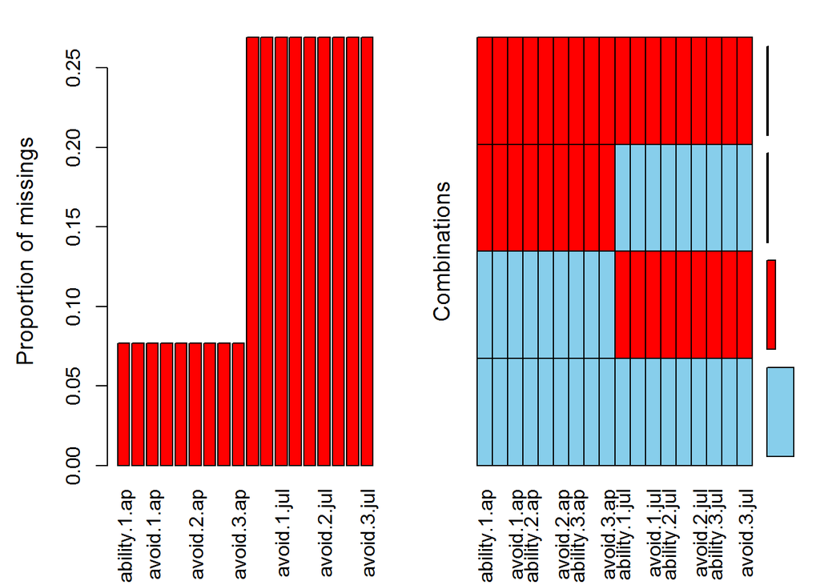

```
##
##  Missings per variable:
##       Variable Count
##   ability.1.ap     2
##   anxiety.1.ap     2
##     avoid.1.ap     2
##   ability.2.ap     2
##   anxiety.2.ap     2
##     avoid.2.ap     2
##   ability.3.ap     2
##   anxiety.3.ap     2
##     avoid.3.ap     2
##  ability.1.jul     7
##  anxiety.1.jul     7
##    avoid.1.jul     7
##  ability.2.jul     7
##  anxiety.2.jul     7
##    avoid.2.jul     7
##  ability.3.jul     7
##  anxiety.3.jul     7
##    avoid.3.jul     7
##
##  Missings in combinations of variables:
##                         Combinations Count   Percent
##  0:0:0:0:0:0:0:0:0:0:0:0:0:0:0:0:0:0    18 69.230769
##  0:0:0:0:0:0:0:0:0:1:1:1:1:1:1:1:1:1     6 23.076923
##  1:1:1:1:1:1:1:1:1:0:0:0:0:0:0:0:0:0     1  3.846154
##  1:1:1:1:1:1:1:1:1:1:1:1:1:1:1:1:1:1     1  3.846154
```

```r
noID%>%
  dplyr::select(ability.1.ap:avoid.3.jul)%>%
  aggr%>%
  summary
```

# 6 Multiple Imputation by mice

```r
m<-20 #define the numer of data sets to be created
imp_data<-mice(noID,m,method="pmm",printFlag = F,maxit = 50,seed = 1)
```

# 7 Summarize the data

Since the imputed data sets were not summarized as three sub-components (ability, anxiety, avoidance), we need to calculate the mean scores of each sub-component.

#### 7.0.0.1 Prepare lists and data frames

```r
imp_list<-list() #prepare a list
imp_list$april<-list() #prepare a list for April data
imp_list$april$all<-matrix(nrow = nrow(noID),ncol=m) #prepare a data frame for all items
imp_list$april$ability<-matrix(nrow = nrow(noID),ncol=m) #prepare a data frame for ability
imp_list$april$anxiety<-matrix(nrow = nrow(noID),ncol=m) #prepare a data frame for anxiety
imp_list$april$avoid<-matrix(nrow = nrow(noID),ncol=m) #prepare a data frame for avoidance

imp_list$july<-list() #prepare a list for July data
imp_list$july$all<-matrix(nrow = nrow(noID),ncol=m) #prepare a data frame for all items
imp_list$july$ability<-matrix(nrow = nrow(noID),ncol=m) #prepare a data frame for ability
imp_list$july$anxiety<-matrix(nrow = nrow(noID),ncol=m) #prepare a data frame for anxiety
imp_list$july$avoid<-matrix(nrow = nrow(noID),ncol=m) #prepare a data frame for avoidance
```

## 7.1 All items

```r
#April
for (i in 1:m){
  mice::complete(imp_data,i)%>%
    dplyr::select(ends_with("ap"))%>%
    apply(.,1,mean)->imp_list$april$all[,i]
}

#July
for (i in 1:m){
  mice::complete(imp_data,i)%>%
    dplyr::select(ends_with("jul")) %>%
    apply(.,1,mean)->imp_list$july$all[,i]
}
```

### 7.1.1 Descriptive Statistics (All items)

```r
apply(imp_list$april$all,1,mean)%>%describe #April
```

```
##    vars  n mean   sd median trimmed  mad  min  max range  skew kurtosis
## X1    1 26 5.39 0.71   5.33    5.42 0.82 3.56 6.44  2.89 -0.36    -0.24
##      se
## X1 0.14
```

```r
apply(imp_list$july$all,1,mean)%>%describe #July
```

```
##    vars  n mean   sd median trimmed  mad  min  max range skew kurtosis
## X1    1 26 4.56 0.88    4.6    4.52 0.59 2.56 6.89  4.33 0.52     0.84
##      se
## X1 0.17
```

## 7.2 Ability

```r
for (i in 1:m){
  mice::complete(imp_data,i)%>%
    dplyr::select(starts_with("ability"))%>%
    dplyr::select(ends_with("ap")) %>%
    apply(.,1,mean)->imp_list$april$ability[,i]
}

for (i in 1:m){
  mice::complete(imp_data,i)%>%
    dplyr::select(starts_with("ability"))%>%
    dplyr::select(ends_with("jul")) %>%
    apply(.,1,mean)->imp_list$july$ability[,i]
}
```

### 7.2.1 Descriptive Statistics (Ability)

```r
apply(imp_list$april$ability,1,mean)%>%describe #April
```

```
##    vars  n mean   sd median trimmed  mad  min max range  skew kurtosis  se
## X1    1 26  5.6 1.03   5.67    5.63 1.48 3.67   7  3.33 -0.31    -1.18 0.2
```

```r
apply(imp_list$july$ability,1,mean)%>%describe #July
```

```
##    vars  n mean   sd median trimmed  mad min max range  skew kurtosis   se
## X1    1 26 4.56 1.16   4.59    4.57 0.94   2   7     5 -0.13    -0.03 0.23
```

## 7.3 Anxiety

```r
for (i in 1:m){
  mice::complete(imp_data,i)%>%
    dplyr::select(starts_with("anxiety"))%>%
    dplyr::select(ends_with("ap")) %>%
    apply(.,1,mean)->imp_list$april$anxiety[,i]
}

for (i in 1:m){
  mice::complete(imp_data,i)%>%
    dplyr::select(starts_with("anxiety"))%>%
    dplyr::select(ends_with("jul")) %>%
    apply(.,1,mean)->imp_list$july$anxiety[,i]
}
```

### 7.3.1 Descriptive Statistics (Anxiety)

```r
apply(imp_list$april$anxiety,1,mean)%>%describe #April
```

```
##    vars  n mean   sd median trimmed  mad  min max range  skew kurtosis
## X1    1 26 5.86 0.98      6    5.97 0.99 3.33   7  3.67 -0.86     0.32
##      se
## X1 0.19
```

```r
apply(imp_list$july$anxiety,1,mean)%>%describe #July
```

```
##    vars  n mean   sd median trimmed  mad  min max range skew kurtosis   se
## X1    1 26    5 0.82      5    4.95 0.49 3.33   7  3.67 0.51     0.29 0.16
```

## 7.4 Avoidance

```r
for (i in 1:m){
  mice::complete(imp_data,i)%>%
    dplyr::select(starts_with("avoid"))%>%
    dplyr::select(ends_with("ap")) %>%
    apply(.,1,mean)->imp_list$april$avoid[,i]
}

for (i in 1:m){
  mice::complete(imp_data,i)%>%
    dplyr::select(starts_with("avoid"))%>%
    dplyr::select(ends_with("jul")) %>%
    apply(.,1,mean)->imp_list$july$avoid[,i]
}
```

### 7.4.1 Descriptive Statistics (Avoidance)

```r
apply(imp_list$april$avoid,1,mean)%>%describe #April
```

```
##    vars  n mean   sd median trimmed  mad min  max range  skew kurtosis
## X1    1 26  4.7 1.18   4.83    4.72 1.24   2 6.67  4.67 -0.19    -0.58
##      se
## X1 0.23
```

```r
apply(imp_list$july$avoid,1,mean)%>%describe #July
```

```
##    vars  n mean   sd median trimmed  mad min max range skew kurtosis   se
## X1    1 26 4.13 1.19    4.1    4.06 1.28   2   7     5 0.47    -0.04 0.23
```

## 7.5 Check normality

```r
normal<-list()
normal$april$all<-apply(imp_list$april$all,2,shapiro.test) #All items for April
normal$july$all<-apply(imp_list$july$all,2,shapiro.test) #All items for July

normal$april$ability<-apply(imp_list$april$ability,2,shapiro.test) #Ability for April
normal$july$ability<-apply(imp_list$july$ability,2,shapiro.test) #Ability for July

normal$april$anxiety<-apply(imp_list$april$anxiety,2,shapiro.test) #Anxiety for April
normal$july$anxiety<-apply(imp_list$july$anxiety,2,shapiro.test) #Anxiety for July

normal$april$avoid<-apply(imp_list$april$avoid,2,shapiro.test) #Avoidance for April
normal$april$avoid<-apply(imp_list$july$avoid,2,shapiro.test) #Avoidance for July
```

## 7.6 Check how many data sets violate normality

```r
list.filter(normal$april$all,p.value<.05)%>%length #All items for April
```

```
## [1] 0
```

```r
list.filter(normal$july$all,p.value<.05)%>%length #All items for July
```

```
## [1] 0
```

```r
list.filter(normal$april$ability,p.value<.05)%>%length #Ability for April
```

```
## [1] 4
```

```r
list.filter(normal$july$ability,p.value<.05)%>%length #Ability for July
```

```
## [1] 0
```

```r
list.filter(normal$april$anxiety,p.value<.05)%>%length #Anxiety for April
```

```
## [1] 20
```

```r
list.filter(normal$july$anxiety,p.value<.05)%>%length #Anxiety for July
```

```
## [1] 0
```

```r
list.filter(normal$april$avoid,p.value<.05)%>%length #Avoidance for April
```

```
## [1] 0
```

```r
list.filter(normal$july$avoid,p.value<.05)%>%length #Avoidance for July
```

```
## [1] 0
```

We can see that some of the data sets for the Ability in April showed p values lower than .05 in the Shapiro-Wilk normality test, indicating that these were not normaliy distributed. In addition, all the data sets for the Anxiety in April were also not normality distributed. Therefore, for those data sets, we are going to perform non-parametric Wilkoxon Singed Rank Tests as well.

# 8 Paired sample t-tests

## 8.1 All items

```r
r.all<-data.frame(t=rep(0,m),p.value=rep(0,m),r=rep(0,m),LowerCI=rep(0,m),UpperCI=rep(0,m)) #prepare a data frame
#print(r.anxiety)

#Repeat paired sample t-tests.
for (i in 1:m){
  result<-0
  result<-t.test(imp_list$april$all[,i],imp_list$july$all[,i],paired = T) #perform t-test
  t<-0
  t<-result$statistic #get t-value
  p<-result$p.value #get p-value
  r.all[i,1]<-round(t,3)
  r.all[i,2]<-p
  df<-0
  df<-result$parameter #get degree of freedom
  r<-0
  r<-sqrt((t^2)/(t^2+df)) #get effect size r
  r.all[i,3]<-r
  r.all[i,4:5]<-CIr(r = r,n = df+1,0.95) #get 95%CI
}
print(r.all)
```

```
##        t      p.value         r   LowerCI   UpperCI
## 1  4.058 4.272210e-04 0.6301375 0.3211810 0.8178617
## 2  5.275 1.832171e-05 0.7257762 0.4707731 0.8688638
## 3  3.338 2.646223e-03 0.5552055 0.2138425 0.7757292
## 4  4.713 7.836435e-05 0.6859256 0.4066069 0.8479751
## 5  4.316 2.192624e-04 0.6534409 0.3562634 0.8305668
## 6  4.705 7.998161e-05 0.6853178 0.4056491 0.8476526
## 7  5.148 2.543872e-05 0.7173284 0.4569416 0.8644778
## 8  4.257 2.551751e-04 0.6483076 0.3484627 0.8277838
## 9  4.686 8.405767e-05 0.6838328 0.4033117 0.8468641
## 10 3.990 5.086864e-04 0.6237153 0.3116595 0.8143278
## 11 4.078 4.058919e-04 0.6319955 0.3239474 0.8188814
## 12 4.522 1.286600e-04 0.6707610 0.3828924 0.8398918
## 13 4.755 7.028361e-05 0.6891398 0.4116822 0.8496788
## 14 4.114 3.694378e-04 0.6353787 0.3289982 0.8207353
## 15 4.875 5.154803e-05 0.6980814 0.4258920 0.8544007
## 16 3.771 8.907206e-04 0.6021086 0.2800788 0.8023338
## 17 4.829 5.807694e-05 0.6946790 0.4204691 0.8526070
## 18 4.607 1.031398e-04 0.6776309 0.3935888 0.8435630
## 19 4.683 8.466275e-05 0.6836179 0.4029736 0.8467499
## 20 4.899 4.842557e-05 0.6998460 0.4287122 0.8553295
```

```r
apply(r.all,2,mean)%>%round(.,3)
```

```
##       t p.value       r LowerCI UpperCI
##   4.481   0.000   0.665   0.375   0.836
```

## 8.2 Ability

### 8.2.1 Wilcoxsign_test

```r
wilcox.result.ability<-data.frame(z.score=rep(0,m),p.value=rep(0,m),r=rep(0,m),LowerCI=rep(0,m),UpperCI=rep(0,m))
for (i in 1:m){
  result<-0
  result<-wilcoxsign_test(imp_list$april$ability[,i]~imp_list$july$ability[,i],distribution="exact")
  wilcox.result.ability[i,1] <- result@statistic@teststatistic #extract z score
  wilcox.result.ability[i,2] <- pvalue(result) #p value for the test
  wilcox.result.ability[i,3] <- wilcox.result.ability[i,1]/sqrt(nrow(imp_list$july$ability)) #effect size r
  wilcox.result.ability[i,4:5] <- CIr(r = wilcox.result.ability[i,3],n = nrow(imp_list$july$ability),0.95)
}
print(wilcox.result.ability)
```

```
##     z.score      p.value         r   LowerCI   UpperCI
## 1  3.654939 7.557869e-05 0.7167925 0.4560684 0.8641988
## 2  3.718614 4.673004e-05 0.7292802 0.4765471 0.8706764
## 3  3.236391 6.690025e-04 0.6347085 0.3279963 0.8203683
## 4  4.142397 2.145767e-06 0.8123908 0.6202061 0.9125732
## 5  4.065261 3.814697e-06 0.7972633 0.5930616 0.9051007
## 6  3.784591 3.433228e-05 0.7422194 0.4980597 0.8773369
## 7  3.753169 3.886223e-05 0.7360569 0.4877764 0.8741712
## 8  3.449921 2.303123e-04 0.6765851 0.3919555 0.8430052
## 9  3.616632 8.487701e-05 0.7092799 0.4438799 0.8602782
## 10 3.486982 1.859665e-04 0.6838534 0.4033440 0.8468750
## 11 3.500758 1.716614e-04 0.6865551 0.4075995 0.8483090
## 12 3.947523 9.536743e-06 0.7741730 0.5525048 0.8935650
## 13 3.829659 2.312660e-05 0.7510579 0.5129293 0.8818568
## 14 3.738632 4.291534e-05 0.7332061 0.4830424 0.8727027
## 15 3.466727 2.093315e-04 0.6798810 0.3971090 0.8447621
## 16 3.295021 4.985332e-04 0.6462069 0.3452824 0.8266424
## 17 3.870963 1.788139e-05 0.7591583 0.5266837 0.8859782
## 18 3.886375 1.430511e-05 0.7621809 0.5318475 0.8875110
## 19 3.886849 1.955032e-05 0.7622737 0.5320064 0.8875580
## 20 4.064601 3.814697e-06 0.7971339 0.5928313 0.9050365
```

```r
apply(wilcox.result.ability,2,mean)%>%round(.,3)
```

```
## z.score p.value       r LowerCI UpperCI
##   3.720   0.000   0.730   0.479   0.870
```

### 8.2.2 Paired Sample t-tests

```r
r.ability<-data.frame(t=rep(0,m),p.value=rep(0,m),r=rep(0,m),LowerCI=rep(0,m),UpperCI=rep(0,m)) #prepare a data frame
#print(r.anxiety)

#Repeat paired sample t-tests.
for (i in 1:m){
  result<-0
  result<-t.test(imp_list$april$ability[,i],imp_list$july$ability[,i],paired = T) #perform t-test
  t<-0
  t<-result$statistic #get t-value
  p<-result$p.value #get p-value
  r.ability[i,1]<-round(t,3)
  r.ability[i,2]<-p
  df<-0
  df<-result$parameter #get degree of freedom
  r<-0
  r<-sqrt((t^2)/(t^2+df)) #get effect size r
  r.ability[i,3]<-r
  r.ability[i,4:5]<-CIr(r = r,n = df+1,0.95) #get 95%CI
}
print(r.ability)
```

```
##        t      p.value         r   LowerCI   UpperCI
## 1  5.131 2.656539e-05 0.7161901 0.4550874 0.8638851
## 2  5.104 2.847181e-05 0.7143584 0.4521086 0.8629305
## 3  4.185 3.076189e-04 0.6418503 0.3387088 0.8242705
## 4  6.248 1.548341e-06 0.7807833 0.5640091 0.8968836
## 5  6.116 2.155270e-06 0.7742074 0.5525643 0.8935823
## 6  4.948 4.267695e-05 0.7033771 0.4343716 0.8571851
## 7  5.408 1.300634e-05 0.7342823 0.4848279 0.8732574
## 8  4.706 7.982083e-05 0.6853777 0.4057435 0.8476844
## 9  4.788 6.457754e-05 0.6916132 0.4155993 0.8509875
## 10 4.725 7.593901e-05 0.6868582 0.4080777 0.8484698
## 11 4.751 7.098226e-05 0.6888494 0.4112228 0.8495250
## 12 5.786 4.963142e-06 0.7566048 0.5223347 0.8846812
## 13 5.724 5.809190e-06 0.7531101 0.5164023 0.8829028
## 14 5.303 1.703725e-05 0.7276069 0.4737870 0.8698113
## 15 4.230 2.735871e-04 0.6459179 0.3448454 0.8264852
## 16 3.847 7.334042e-04 0.6097816 0.2912146 0.8066118
## 17 5.334 1.576105e-05 0.7295520 0.4769960 0.8708169
## 18 5.368 1.443619e-05 0.7317261 0.4805907 0.8719395
## 19 6.032 2.660230e-06 0.7699059 0.5451231 0.8914158
## 20 5.718 5.891244e-06 0.7527959 0.5158701 0.8827427
```

```r
apply(r.ability,2,mean)%>%round(.,3)
```

```
##       t p.value       r LowerCI UpperCI
##   5.173   0.000   0.715   0.454   0.863
```

## 8.3 Anxiety

### 8.3.1 Wilcoxsign_test

```r
wilcox.result.anxiety<-data.frame(z.score=rep(0,m),p.value=rep(0,m),r=rep(0,m),LowerCI=rep(0,m),UpperCI=rep(0,m))
for (i in 1:m){
  result<-0
  result<-wilcoxsign_test(imp_list$april$anxiety[,i]~imp_list$july$anxiety[,i],distribution="exact")
  wilcox.result.anxiety[i,1] <- result@statistic@teststatistic #extract z score
  wilcox.result.anxiety[i,2] <- pvalue(result) #p value for the test
  wilcox.result.anxiety[i,3] <- wilcox.result.anxiety[i,1]/sqrt(nrow(imp_list$july$anxiety)) #effect size r
  wilcox.result.anxiety[i,4:5] <- CIr(r = wilcox.result.anxiety[i,3],n = nrow(imp_list$july$anxiety),0.95)
}
print(wilcox.result.anxiety)
```

```
##     z.score      p.value         r    LowerCI   UpperCI
## 1  2.902869 2.669334e-03 0.5692995 0.23342147 0.7838069
## 2  3.632416 8.201599e-05 0.7123753 0.44889014 0.8618958
## 3  2.877989 2.912760e-03 0.5644200 0.22661208 0.7810185
## 4  3.003386 1.787186e-03 0.5890124 0.26127069 0.7949846
## 5  3.170496 8.912086e-04 0.6217854 0.30881031 0.8132631
## 6  3.346451 3.819466e-04 0.6562931 0.36061558 0.8321092
## 7  3.565216 1.201630e-04 0.6991964 0.42767341 0.8549877
## 8  2.671639 6.165624e-03 0.5239515 0.17138221 0.7575549
## 9  3.018312 1.667261e-03 0.5919398 0.26545338 0.7966326
## 10 3.167544 8.908510e-04 0.6212065 0.30795687 0.8129435
## 11 3.003021 1.791477e-03 0.5889409 0.26116864 0.7949442
## 12 3.039965 1.529813e-03 0.5961861 0.27154254 0.7990178
## 13 2.927858 2.405524e-03 0.5742003 0.24029392 0.7865988
## 14 2.929758 2.405882e-03 0.5745728 0.24081773 0.7868107
## 15 3.536312 1.451969e-04 0.6935278 0.41863870 0.8519992
## 16 2.864441 3.082514e-03 0.5617632 0.22291825 0.7794966
## 17 3.097238 1.208067e-03 0.6074184 0.28777565 0.8052964
## 18 2.188908 2.721620e-02 0.4292802 0.05029075 0.7002010
## 19 3.402171 2.977848e-04 0.6672207 0.37741005 0.8379938
## 20 3.257251 6.145239e-04 0.6387994 0.33412287 0.8226056
```

```r
apply(wilcox.result.anxiety,2,mean)%>%round(.,3)
```

```
## z.score p.value       r LowerCI UpperCI
##   3.080   0.003   0.604   0.286   0.803
```

### 8.3.2 Paired Sample t-tests

```r
r.anxiety<-data.frame(t=rep(0,m),p.value=rep(0,m),r=rep(0,m),LowerCI=rep(0,m),UpperCI=rep(0,m)) #prepare a data frame
#print(r.anxiety)

#Repeat paired sample t-tests.
for (i in 1:m){
  result<-0
  result<-t.test(imp_list$april$anxiety[,i],imp_list$july$anxiety[,i],paired = T) #perform t-test
  t<-0
  t<-result$statistic #get t-value
  p<-result$p.value #get p-value
  r.anxiety[i,1]<-round(t,3)
  r.anxiety[i,2]<-p
  df<-0
  df<-result$parameter #get degree of freedom
  r<-0
  r<-sqrt((t^2)/(t^2+df)) #get effect size r
  r.anxiety[i,3]<-r
  r.anxiety[i,4:5]<-CIr(r = r,n = df+1,0.95) #get 95%CI
}
print(r.anxiety)
```

```
##        t      p.value         r    LowerCI   UpperCI
## 1  3.443 2.038042e-03 0.5671046 0.23035437 0.7825537
## 2  5.054 3.243555e-05 0.7108756 0.44646065 0.8611124
## 3  3.176 3.940918e-03 0.5361751 0.18783410 0.7647063
## 4  3.729 9.893329e-04 0.5978807 0.27397987 0.7999679
## 5  3.836 7.540438e-04 0.6086976 0.28963619 0.8060087
## 6  4.292 2.334963e-04 0.6513237 0.35304103 0.8294200
## 7  4.641 9.447467e-05 0.6803091 0.39777973 0.8449901
## 8  3.305 2.866164e-03 0.5514783 0.20871024 0.7735808
## 9  3.715 1.024805e-03 0.5964491 0.27192058 0.7991653
## 10 4.056 4.287873e-04 0.6300043 0.32098288 0.8177885
## 11 3.766 9.014533e-04 0.6016292 0.27938606 0.8020659
## 12 3.715 1.024805e-03 0.5964491 0.27192058 0.7991653
## 13 3.601 1.370161e-03 0.5843864 0.25468603 0.7923740
## 14 3.560 1.517397e-03 0.5800336 0.24851790 0.7899106
## 15 4.629 9.744895e-05 0.6793662 0.39630291 0.8444879
## 16 3.249 3.294895e-03 0.5448668 0.19965257 0.7697574
## 17 3.800 8.274143e-04 0.6050425 0.28432652 0.8039720
## 18 2.389 2.478312e-02 0.4310535 0.05246098 0.7013084
## 19 4.185 3.077571e-04 0.6418346 0.33868521 0.8242619
## 20 4.073 4.105837e-04 0.6315796 0.32332769 0.8186533
```

```r
apply(r.anxiety,2,mean)%>%round(.,3)
```

```
##       t p.value       r LowerCI UpperCI
##   3.811   0.002   0.601   0.281   0.801
```

## 8.4 Avoidance

```r
r.avoid<-data.frame(t=rep(0,m),p.value=rep(0,m),r=rep(0,m),LowerCI=rep(0,m),UpperCI=rep(0,m)) #prepare a data frame
#print(r.anxiety)

#Repeat paired sample t-tests.
for (i in 1:m){
  result<-0
  result<-t.test(imp_list$april$avoid[,i],imp_list$july$avoid[,i],paired = T) #perform t-test
  t<-0
  t<-result$statistic #get t-value
  p<-result$p.value #get p-value
  r.avoid[i,1]<-round(t,3)
  r.avoid[i,2]<-p
  df<-0
  df<-result$parameter #get degree of freedom
  r<-0
  r<-sqrt((t^2)/(t^2+df)) #get effect size r
  r.avoid[i,3]<-r
  r.avoid[i,4:5]<-CIr(r = r,n = df+1,0.95) #get 95%CI
}
print(r.avoid)
```

```
##        t    p.value         r      LowerCI   UpperCI
## 1  1.610 0.11995357 0.3065024 -0.091741511 0.6202192
## 2  2.022 0.05401320 0.3748874 -0.014582081 0.6655872
## 3  1.132 0.26829859 0.2208464 -0.182081747 0.5602699
## 4  1.165 0.25517337 0.2268482 -0.175965858 0.5645896
## 5  0.990 0.33153939 0.1942768 -0.208787110 0.5409224
## 6  1.594 0.12354304 0.3037069 -0.094797159 0.6183189
## 7  2.154 0.04103746 0.3957142  0.009876043 0.6789901
## 8  2.270 0.03206048 0.4134491  0.031073628 0.6902563
## 9  2.142 0.04210071 0.3938253  0.007638660 0.6777823
## 10 1.284 0.21100058 0.2486843 -0.153449178 0.5801512
## 11 1.703 0.10088912 0.3224850 -0.074126482 0.6310137
## 12 1.714 0.09898361 0.3242028 -0.072218384 0.6321668
## 13 2.169 0.03977573 0.3980068  0.012596872 0.6804540
## 14 1.636 0.11427208 0.3110557 -0.086748421 0.6233066
## 15 1.617 0.11853006 0.3076280 -0.090508975 0.6209834
## 16 1.250 0.22303905 0.2424521 -0.159918496 0.5757343
## 17 1.503 0.14524721 0.2879571 -0.111873235 0.6075432
## 18 2.434 0.02240991 0.4377064  0.060634844 0.7054515
## 19 1.648 0.11190931 0.3129985 -0.084611810 0.6246210
## 20 1.357 0.18676015 0.2620097 -0.139500100 0.5895302
```

```r
apply(r.avoid,2,mean)%>%round(.,3)
```

```
##       t p.value       r LowerCI UpperCI
##   1.670   0.132   0.314  -0.081   0.624
```

```r
r.avoid$LowerCI[r.avoid$LowerCI< 0]%>%length
```

```
## [1] 15
```

```r
r.avoid$p.value[r.avoid$p.value< .05]%>%length
```

```
## [1] 5
```

# 9 Visualization

## 9.1 All items

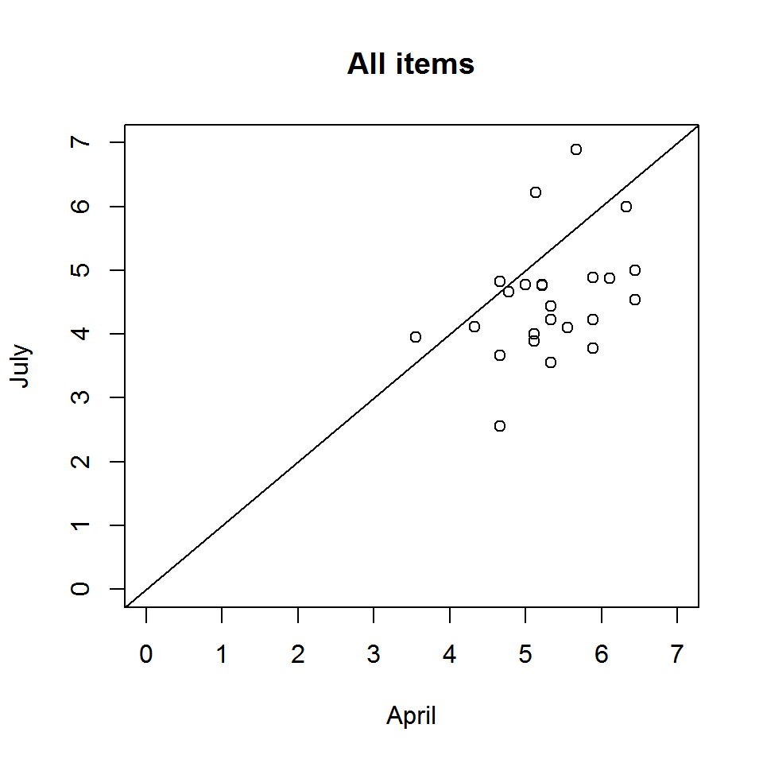

```r
plot(apply(imp_list$april$all,1,mean),apply(imp_list$july$all,1,mean)
     ,xlab="April",ylab="July"
     ,xlim=c(0,7),ylim=c(0,7)
     ,main="All items")
abline(0,1)
```

## 9.2 Ability

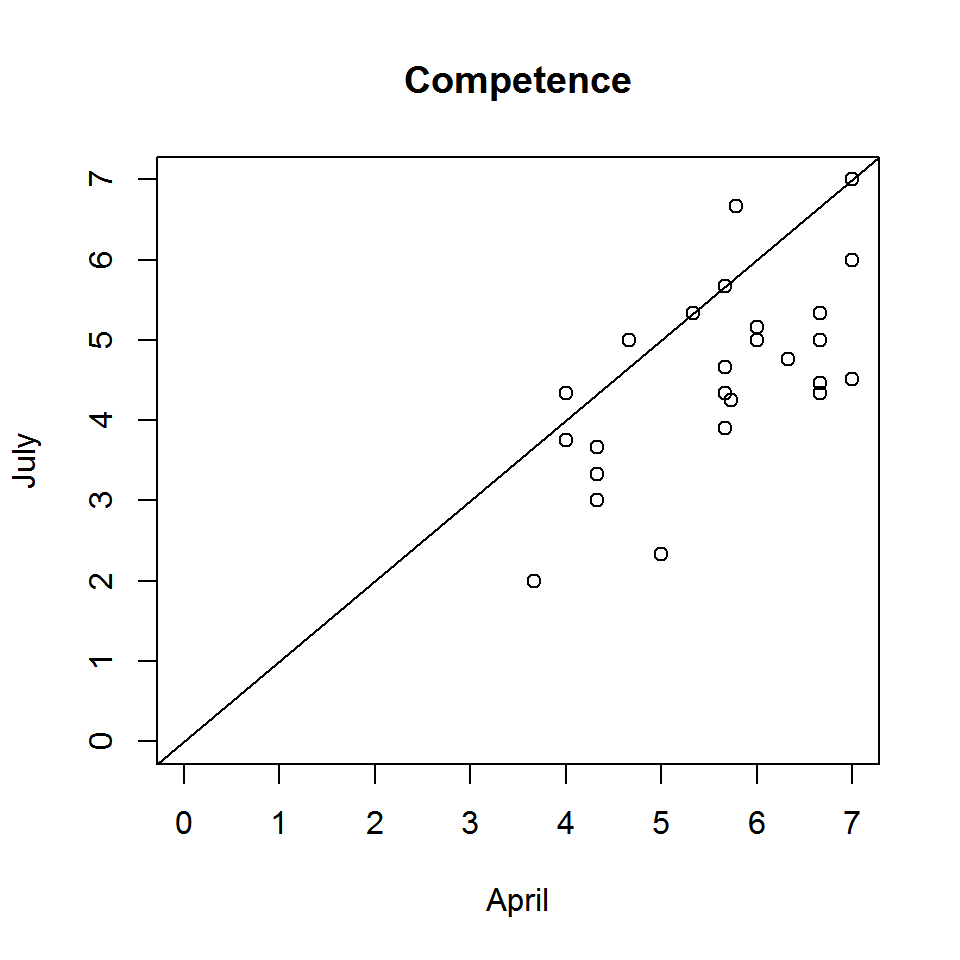

```r
plot(apply(imp_list$april$ability,1,mean),apply(imp_list$july$ability,1,mean)
     ,xlab="April",ylab="July"
     ,xlim=c(0,7),ylim=c(0,7)
     ,main="Competence")
abline(0,1)
```

## 9.3 Anxiety

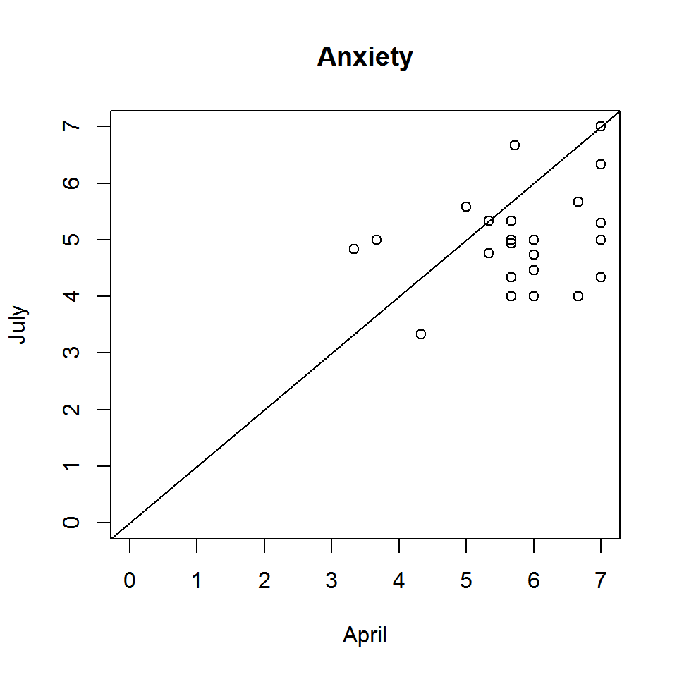

```r
plot(apply(imp_list$april$anxiety,1,mean),apply(imp_list$july$anxiety,1,mean)
     ,xlab="April",ylab="July"
     ,xlim=c(0,7),ylim=c(0,7)
     ,main="Anxiety")
abline(0,1)
```

## 9.4 Avoidance

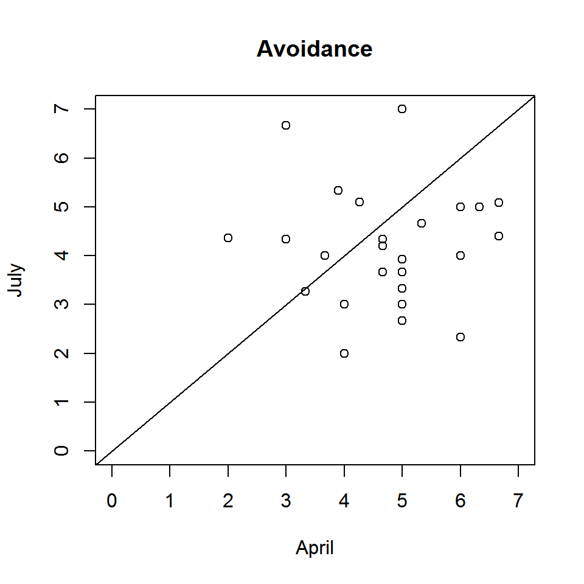

```r
plot(apply(imp_list$april$avoid,1,mean),apply(imp_list$july$avoid,1,mean)
     ,xlab="April",ylab="July"
     ,xlim=c(0,7),ylim=c(0,7)
     ,main="Avoidance")
abline(0,1)
```

# 10 List-wise deletion (Just for reference)

```r
noID%>%
  na.exclude%>%
  dplyr::select(ability.1.ap:avoid.3.jul)->listwise.dat
```

## 10.1 Stats

```r
listwise.dat2<-data.frame(ability.ap=rep(0,nrow(listwise.dat)),
                          anxiety.ap=rep(0,nrow(listwise.dat)),
                          avoid.ap=rep(0,nrow(listwise.dat)),
                          all.ap=rep(0,nrow(listwise.dat)),
                          ability.jul=rep(0,nrow(listwise.dat)),
                          anxiety.jul=rep(0,nrow(listwise.dat)),
                          avoid.jul=rep(0,nrow(listwise.dat)),
                          all.jul=rep(0,nrow(listwise.dat)))
listwise.dat%>%
  dplyr::select(starts_with("ability")) %>%
  dplyr::select(ends_with("ap"))%>%
  apply(.,1,mean)->listwise.dat2$ability.ap

listwise.dat%>%
  dplyr::select(starts_with("anxiety")) %>%
  dplyr::select(ends_with("ap"))%>%
  apply(.,1,mean)->listwise.dat2$anxiety.ap

listwise.dat%>%
  dplyr::select(starts_with("avoid")) %>%
  dplyr::select(ends_with("ap"))%>%
  apply(.,1,mean)->listwise.dat2$avoid.ap

listwise.dat%>%
  dplyr::select(ends_with("ap"))%>%
  apply(.,1,mean)->listwise.dat2$all.ap

listwise.dat%>%
  dplyr::select(starts_with("ability")) %>%
  dplyr::select(ends_with("jul"))%>%
  apply(.,1,mean)->listwise.dat2$ability.jul

listwise.dat%>%
  dplyr::select(starts_with("anxiety")) %>%
  dplyr::select(ends_with("jul"))%>%
  apply(.,1,mean)->listwise.dat2$anxiety.jul

listwise.dat%>%
  dplyr::select(starts_with("avoid")) %>%
  dplyr::select(ends_with("jul"))%>%
  apply(.,1,mean)->listwise.dat2$avoid.jul

listwise.dat%>%
  dplyr::select(ends_with("jul"))%>%
  apply(.,1,mean)->listwise.dat2$all.jul

sapply(listwise.dat2,describe,simplify = T)%>%t()
```

```
##             vars n  mean     sd        median   trimmed  mad
## ability.ap  1    18 5.462963 1.073379  5.666667 5.479167 1.4826
## anxiety.ap  1    18 6.018519 0.9391431 6        6.104167 0.9884
## avoid.ap    1    18 4.759259 0.9954508 5        4.770833 1.4826
## all.ap      1    18 5.41358  0.632921  5.333333 5.416667 0.8236667
## ability.jul 1    18 4.5      1.269296  4.666667 4.5      0.9884
## anxiety.jul 1    18 4.925926 0.8748898 5        4.895833 0.7413
## avoid.jul   1    18 3.981481 1.350247  3.833333 3.916667 1.2355
## all.jul     1    18 4.469136 0.9577536 4.333333 4.4375   0.7413
##             min      max      range    skew        kurtosis    se
## ability.ap  3.666667 7        3.333333 -0.05276958 -1.414811   0.2529978
## anxiety.ap  3.666667 7        3.333333 -0.8731444  0.1375871   0.2213582
## avoid.ap    3        6.333333 3.333333 -0.2038568  -1.022358   0.23463
## all.ap      4.333333 6.444444 2.111111 0.1800624   -1.155957   0.1491809
## ability.jul 2        7        5        -0.2505387  -0.5251354  0.2991758
## anxiety.jul 3.333333 7        3.666667 0.4494318   0.003054303 0.2062135
## avoid.jul   2        7        5        0.7150579   -0.2226337  0.3182562
## all.jul     2.555556 6.888889 4.333333 0.5820275   0.6260787   0.2257447
```

## 10.2 Paired *t*-tests

```r
head(listwise.dat2)
```

```
##   ability.ap anxiety.ap avoid.ap   all.ap ability.jul anxiety.jul
## 1   3.666667   4.333333 6.000000 4.666667    2.000000    3.333333
## 2   5.000000   6.000000 5.000000 5.333333    2.333333    5.000000
## 3   5.666667   5.333333 4.666667 5.222222    4.666667    5.333333
## 4   6.000000   7.000000 6.333333 6.444444    5.000000    5.000000
## 5   5.666667   7.000000 5.000000 5.888889    4.333333    4.333333
## 6   5.333333   3.666667 4.000000 4.333333    5.333333    5.000000
##   avoid.jul  all.jul
## 1  2.333333 2.555556
## 2  3.333333 3.555556
## 3  4.333333 4.777778
## 4  5.000000 5.000000
## 5  2.666667 3.777778
## 6  2.000000 4.111111
```

```r
#apply(listwise.dat2,2,shapiro.test)

t.test(listwise.dat2$all.ap,listwise.dat2$all.jul,paired=T)
```

```
##
##  Paired t-test
##
## data:  listwise.dat2$all.ap and listwise.dat2$all.jul
## t = 4.8433, df = 17, p-value = 0.0001523
## alternative hypothesis: true difference in means is not equal to 0
## 95 percent confidence interval:
##  0.5330277 1.3558612
## sample estimates:
## mean of the differences
##               0.9444444
```

```r
t.test(listwise.dat2$ability.ap,listwise.dat2$ability.jul,paired=T)
```

```
##
##  Paired t-test
##
## data:  listwise.dat2$ability.ap and listwise.dat2$ability.jul
## t = 4.7798, df = 17, p-value = 0.0001741
## alternative hypothesis: true difference in means is not equal to 0
## 95 percent confidence interval:
##  0.5379127 1.3880132
## sample estimates:
## mean of the differences
##                0.962963
```

```r
t.test(listwise.dat2$anxiety.ap,listwise.dat2$anxiety.jul,paired=T)
```

```
##
##  Paired t-test
##
## data:  listwise.dat2$anxiety.ap and listwise.dat2$anxiety.jul
## t = 4.6262, df = 17, p-value = 0.0002412
## alternative hypothesis: true difference in means is not equal to 0
## 95 percent confidence interval:
##  0.5943121 1.5908730
## sample estimates:
## mean of the differences
##                1.092593
```

```r
t.test(listwise.dat2$avoid.ap,listwise.dat2$avoid.jul,paired=T)
```

```
##
##  Paired t-test
##
## data:  listwise.dat2$avoid.ap and listwise.dat2$avoid.jul
## t = 1.9199, df = 17, p-value = 0.07182
## alternative hypothesis: true difference in means is not equal to 0
## 95 percent confidence interval:
##  -0.07695773  1.63251328
## sample estimates:
## mean of the differences
##               0.7777778
```

```r
wilcoxsign_test(listwise.dat2$all.ap~listwise.dat2$all.jul,exact=T)
```

```
##
##  Asymptotic Wilcoxon-Pratt Signed-Rank Test
##
## data:  y by x (pos, neg)
##   stratified by block
## Z = 3.2025, p-value = 0.001363
## alternative hypothesis: true mu is not equal to 0
```

```r
wilcoxsign_test(listwise.dat2$ability.ap~listwise.dat2$ability.jul,exact=T)
```

```
##
##  Asymptotic Wilcoxon-Pratt Signed-Rank Test
##
## data:  y by x (pos, neg)
##   stratified by block
## Z = 3.2162, p-value = 0.001299
## alternative hypothesis: true mu is not equal to 0
```

```r
wilcoxsign_test(listwise.dat2$anxiety.ap~listwise.dat2$anxiety.jul,exact=T)
```

```
##
##  Asymptotic Wilcoxon-Pratt Signed-Rank Test
##
## data:  y by x (pos, neg)
##   stratified by block
## Z = 3.189, p-value = 0.001428
## alternative hypothesis: true mu is not equal to 0
```

```r
wilcoxsign_test(listwise.dat2$avoid.ap~listwise.dat2$avoid.jul,exact=T)
```

```
##
##  Asymptotic Wilcoxon-Pratt Signed-Rank Test
##
## data:  y by x (pos, neg)
##   stratified by block
## Z = 1.9414, p-value = 0.0522
## alternative hypothesis: true mu is not equal to 0
```

# 11 Identify the students whose speaking anxiety did not decrease

```r
#Prepare a data frame
deacreasing<-data.frame(all=rep(0,nrow(imp_list$april$all))
                        ,ability=rep(0,nrow(imp_list$april$ability))
                        ,anxiety=rep(0,nrow(imp_list$april$anxiety))
                        ,avoid=rep(0,nrow(imp_list$april$avoid)))

#Decreased -> FALSE; Not decreased -> TRUE
deacreasing$all<-apply(imp_list$april$all,1,mean)<= apply(imp_list$july$all,1,mean)
deacreasing$ability<-apply(imp_list$april$ability,1,mean) <= apply(imp_list$july$ability,1,mean)
deacreasing$anxiety<-apply(imp_list$april$anxiety,1,mean) <= apply(imp_list$july$anxiety,1,mean)
deacreasing$avoid<-apply(imp_list$april$avoid,1,mean) <= apply(imp_list$july$avoid,1,mean)

grep(TRUE,deacreasing$all) #Extracting the rows which has TRUE
```

```
## [1]  6 17 19 24
```

```r
grep(TRUE,deacreasing$ability) #Extracting the rows which has TRUE
```

```
## [1] 10 13 18 19 24 25
```

```r
grep(TRUE,deacreasing$anxiety) #Extracting the rows which has TRUE
```

```
## [1]  3  6 10 17 19 24
```

```r
grep(TRUE,deacreasing$avoid) #Extracting the rows which has TRUE
```

```
## [1]  9 14 16 17 19 24 25
```

| Category | ID |
| --- | --- |
| All items | 6, 17, 19, 24 |
| Competence | 10, 13, 18, 19, 24, 25 |
| Anxiety | 3, 6, 10, 17, 19, 24 |
| Avoidance | 9, 14, 16, 17, 19, 24, 25 |